# Confounder and richness analysis

Christian Diener <mail (a) cdiener.com>

## Additional analyses

```r
library(mbtools)

original <- fread("../data/tests_genus.csv")
original$strategy <- "without"
original$response <- "single"
original$coef <- NA
filtered <- fread("../data/tests_confounders.csv")
filtered$strategy <- "with"

vars <- c("diabetes_status", "auc_glucose", "num_risk_factors", "bmi", "percent_body_fat", "systolic_pressure", "diastolic_pressure")
genera <- original[variable %in% c("diabetes_status", "num_risk_factors")
                & padj < 0.1, names(table(genus))[table(genus) == 2]]
tests <- rbind(original[variable %in% vars], filtered[variable %in% vars])
tests <- tests[genus %in% genera]
tests[, variable := factor(variable, levels=vars)]
tests[, strategy := factor(strategy, levels=c("without", "with"))]
```

### Confounding of associations:

Shown are the log2 fold changes when only considering the clinical variable without additional confounders (only gender as always used) and when using additional confounding variables for the other groups. Basically if you see a horizontal line it would indicate no confounding effect. If the line drops or raises towards zero it indicates that the association is confounded. Error bars denotes the standard error of the log2 fold change (regression coefficient).

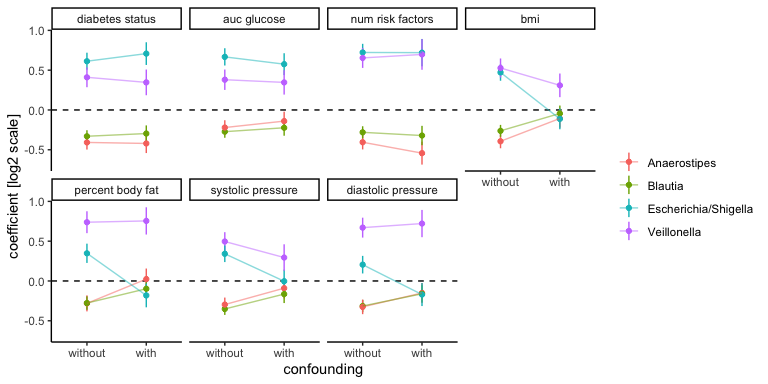

```r
library(ggplot2)
theme_set(theme_classic())

pl <- ggplot(tests, aes(x=strategy, y=log2FoldChange, col=genus, group=genus)) +
  geom_hline(yintercept=0, lty="dashed") +
  geom_linerange(aes(ymin=log2FoldChange - lfcSE, ymax=log2FoldChange + lfcSE)) +
  geom_point() + geom_line(alpha=0.5) +
  facet_wrap(~ variable, nrow=2, labeller = as_labeller(function(x) gsub("_", " ", x))) +
  labs(x="confounding", y="coefficient [log2 scale]", color="")
ggsave("confounding.svg", width=8, height=4)
pl
```

Seems that most associations are actually due to the disease state.

## Diversity

Diversity was calculated using Shannon index.

Just to see that association with diversity does not depend on overall abundance…

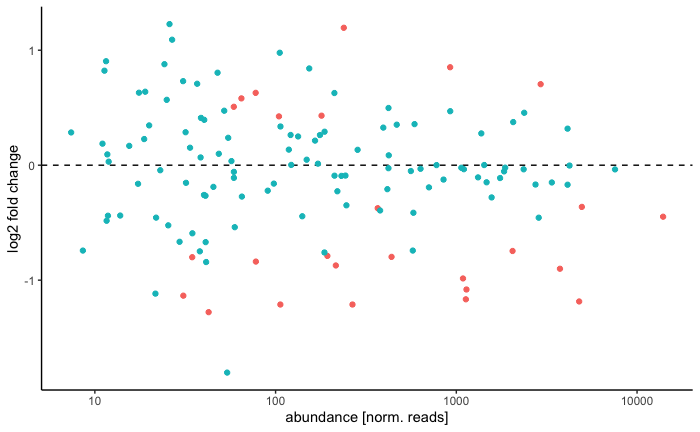

```r
pl <- ggplot(original[variable == "richness"], aes(x=baseMean, y=log2FoldChange, col=(padj > 0.05) | is.na(padj))) +
  geom_hline(yintercept=0, lty="dashed") + geom_point() + scale_x_log10(breaks=c(10, 100, 1000, 10000)) +
  labs(x="abundance [norm. reads]", y="log2 fold change") +
  guides(color=F)
ggsave("abundance_vs_richness_lfc.svg", width=5, height=5)
pl
```

Genera which are associated significantly with diversity (Shannon index). Error bars denotes the standard error of the log2 fold change (regression coefficient).

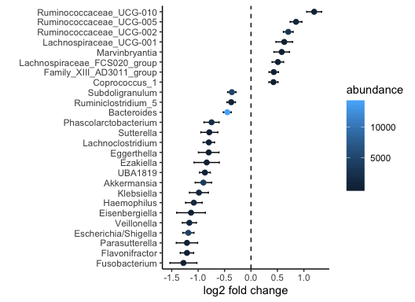

```r
rich <- original[padj < 0.05 & variable == "richness"][order(log2FoldChange)]
rich[, genus := factor(genus, levels=unique(genus))]
pl <- ggplot(rich, aes(y=genus, x=log2FoldChange)) +
  geom_vline(xintercept=0, lty="dashed") +
  geom_errorbarh(aes(xmin=log2FoldChange - lfcSE, xmax=log2FoldChange + lfcSE), height=0.2) +
  geom_point(aes(col=baseMean), size=2) +
  scale_fill_gradient(name="abundance", trans="log") +
  labs(x="log2 fold change", y="", color="abundance")
ggsave("richness_genera.svg", width=5.5, height=4)
pl
```

We find Escherichia and Veillonella but not Anaerostipes and Blautia. So whatever the causality between Anaerostipes/Blautia and Diabetes is it is not simply a restoration of diversity.